# 2025ag05644_assignment1

## Assignment 1 - Deep Neural Networks

### Dataset: Uber & Lyft Rideshare Dataset – Boston, MA

### Task: Regression - Predicting Ride Price

## 4.1 Dataset Selection

### Dataset Description

**Name:** Uber and Lyft Dataset Boston, MA  
**Source:** Kaggle – https://www.kaggle.com/datasets/brllrb/uber-and-lyft-dataset-boston-ma  
**Collection Period:** November 26, 2018 to December 18, 2018 (22 days)

This dataset was collected via real-time API queries to Uber and Lyft services at several hotspot locations in Boston, MA, sampled every 5 minutes over 22 days. It captures ride-level pricing data along with concurrent weather conditions.

**Raw dataset:** ~693,000 rows × 57 columns  
**After cleaning:** 637,628 rows used for training - full dataset, no sampling.

### Problem Type

**Regression** — We predict the continuous `price` variable (ride fare in USD).

[output not shown]

**Total: 14 features**

### Primary Evaluation Metric: RMSE

Root Mean Squared Error (RMSE) is chosen as the primary metric because:

- Fare prediction errors have a direct monetary impact - RMSE penalises large errors more than MAE, which is important when a $10 prediction error is much worse than a $1 error.
- It is in the same unit as the target (USD), making it intuitively interpretable.
- It is the standard metric used in Kaggle's official NYC Taxi Fare Prediction competition, making it an industry norm for ride pricing tasks.

## Imports

```python
import numpy as np
import pandas as pd
import matplotlib.pyplot as plt
import seaborn as sns
import time
import warnings
warnings.filterwarnings('ignore')

from sklearn.model_selection import train_test_split
from sklearn.preprocessing import StandardScaler, LabelEncoder

np.random.seed(42)
print("All imports successful.")
```

```
All imports successful.
```

```python
# ─────────────────────────────────────────────────────────
# STEP 1: Load the dataset
#
# Download from Kaggle:
#   https://www.kaggle.com/datasets/brllrb/uber-and-lyft-dataset-boston-ma
# Place rideshare_kaggle.csv in the same directory as this notebook.
# ─────────────────────────────────────────────────────────

df_raw = pd.read_csv('data/rideshare_kaggle.csv')
print(f"Raw dataset shape: {df_raw.shape}")
print(f"\nColumns:\n{list(df_raw.columns)}")
```

```
Raw dataset shape: (693071, 57)

Columns:
['id', 'timestamp', 'hour', 'day', 'month', 'datetime', 'timezone', 'source', 'destination', 'cab_type', 'product_id', 'name', 'price', 'distance', 'surge_multiplier', 'latitude', 'longitude', 'temperature', 'apparentTemperature', 'short_summary', 'long_summary', 'precipIntensity', 'precipProbabilit…
```

```python
pd.set_option('display.max_columns', None)
pd.set_option('display.max_rows', None)
df_raw.describe()
```

|  | timestamp | hour | day | month | price | distance | surge_multiplier | latitude | longitude | temperature | apparentTemperature | precipIntensity | precipProbability | humidity | windSpeed | windGust | windGustTime | visibility | temperatureHigh | temperatureHighTime | temperatureLow | temperatureLowTime | apparentTemperatureHigh | apparentTemperatureHighTime | apparentTemperatureLow | apparentTemperatureLowTime | dewPoint | pressure | windBearing | … |
| --- | --- | --- | --- | --- | --- | --- | --- | --- | --- | --- | --- | --- | --- | --- | --- | --- | --- | --- | --- | --- | --- | --- | --- | --- | --- | --- | --- | --- | --- | --- |
| count | 6.930710e+05 | 693071.000000 | 693071.000000 | 693071.000000 | 637976.000000 | 693071.000000 | 693071.000000 | 693071.000000 | 693071.000000 | 693071.000000 | 693071.000000 | 693071.000000 | 693071.000000 | 693071.000000 | 693071.000000 | 693071.000000 | 6.930710e+05 | 693071.000000 | 693071.000000 | 6.930710e+05 | 693071.000000 | 6.930710e+05 | 693071.000000 | 6.930710e+05 | 693071.000000 | 6.930710e+05 | 693071.000000 | 693071.000000 | 693071.000000 | … |
| mean | 1.544046e+09 | 11.619137 | 17.794365 | 11.586684 | 16.545125 | 2.189430 | 1.013870 | 42.338172 | -71.066151 | 39.584388 | 35.881222 | 0.008922 | 0.146076 | 0.741119 | 6.186253 | 8.469860 | 1.544049e+09 | 8.467970 | 45.040982 | 1.544050e+09 | 34.150736 | 1.544102e+09 | 41.614054 | 1.544050e+09 | 30.139824 | 1.544099e+09 | 31.656256 | 1010.094766 | 220.055853 | … |
| std | 6.891925e+05 | 6.948114 | 9.982286 | 0.492429 | 9.324359 | 1.138937 | 0.091641 | 0.047840 | 0.020302 | 6.726084 | 7.918707 | 0.026901 | 0.328938 | 0.138595 | 3.148223 | 5.289179 | 6.928244e+05 | 2.602888 | 5.996541 | 6.937921e+05 | 6.383163 | 6.922923e+05 | 7.666138 | 6.941699e+05 | 8.057468 | 6.927378e+05 | 9.142355 | 13.472899 | 99.102736 | … |
| min | 1.543204e+09 | 0.000000 | 1.000000 | 11.000000 | 2.500000 | 0.020000 | 1.000000 | 42.214800 | -71.105400 | 18.910000 | 12.130000 | 0.000000 | 0.000000 | 0.380000 | 0.450000 | 0.800000 | 1.543151e+09 | 0.717000 | 32.680000 | 1.543154e+09 | 17.850000 | 1.543234e+09 | 22.620000 | 1.543187e+09 | 11.810000 | 1.543234e+09 | 4.390000 | 988.090000 | 2.000000 | … |
| 25% | 1.543444e+09 | 6.000000 | 13.000000 | 11.000000 | 9.000000 | 1.280000 | 1.000000 | 42.350300 | -71.081000 | 36.450000 | 31.910000 | 0.000000 | 0.000000 | 0.640000 | 3.410000 | 4.060000 | 1.543432e+09 | 8.432000 | 42.570000 | 1.543439e+09 | 30.170000 | 1.543489e+09 | 36.570000 | 1.543439e+09 | 27.700000 | 1.543478e+09 | 27.490000 | 999.820000 | 124.000000 | … |
| 50% | 1.543737e+09 | 12.000000 | 17.000000 | 12.000000 | 13.500000 | 2.160000 | 1.000000 | 42.351900 | -71.063100 | 40.490000 | 35.900000 | 0.000000 | 0.000000 | 0.710000 | 5.910000 | 7.550000 | 1.543756e+09 | 9.880000 | 44.680000 | 1.543788e+09 | 34.180000 | 1.543817e+09 | 40.950000 | 1.543788e+09 | 30.030000 | 1.543817e+09 | 30.690000 | 1009.250000 | 258.000000 | … |
| 75% | 1.544828e+09 | 18.000000 | 28.000000 | 12.000000 | 22.500000 | 2.920000 | 1.000000 | 42.364700 | -71.054200 | 43.580000 | 40.080000 | 0.000000 | 0.000000 | 0.880000 | 8.410000 | 11.740000 | 1.544846e+09 | 9.996000 | 46.910000 | 1.544814e+09 | 38.730000 | 1.544836e+09 | 44.120000 | 1.544818e+09 | 35.320000 | 1.544836e+09 | 38.120000 | 1021.860000 | 303.000000 | … |
| max | 1.545161e+09 | 23.000000 | 30.000000 | 12.000000 | 97.500000 | 7.860000 | 3.000000 | 42.366100 | -71.033000 | 57.220000 | 57.220000 | 0.144700 | 1.000000 | 0.960000 | 15.000000 | 27.250000 | 1.545127e+09 | 10.000000 | 57.870000 | 1.545160e+09 | 46.600000 | 1.545221e+09 | 57.200000 | 1.545160e+09 | 47.250000 | 1.545199e+09 | 50.670000 | 1035.550000 | 356.000000 | … |

```python
df_raw.head(3)
```

|  | id | timestamp | hour | day | month | datetime | timezone | source | destination | cab_type | product_id | name | price | distance | surge_multiplier | latitude | longitude | temperature | apparentTemperature | short_summary | long_summary | precipIntensity | precipProbability | humidity | windSpeed | windGust | windGustTime | visibility | temperatureHigh | … |
| --- | --- | --- | --- | --- | --- | --- | --- | --- | --- | --- | --- | --- | --- | --- | --- | --- | --- | --- | --- | --- | --- | --- | --- | --- | --- | --- | --- | --- | --- | --- |
| 0 | 424553bb-7174-41ea-aeb4-fe06d4f4b9d7 | 1.544953e+09 | 9 | 16 | 12 | 2018-12-16 09:30:07 | America/New_York | Haymarket Square | North Station | Lyft | lyft_line | Shared | 5.0 | 0.44 | 1.0 | 42.2148 | -71.033 | 42.34 | 37.12 | Mostly Cloudy | Rain throughout the day. | 0.0000 | 0.0 | 0.68 | 8.66 | 9.17 | 1545015600 | 10.000 | 43.68 | … |
| 1 | 4bd23055-6827-41c6-b23b-3c491f24e74d | 1.543284e+09 | 2 | 27 | 11 | 2018-11-27 02:00:23 | America/New_York | Haymarket Square | North Station | Lyft | lyft_premier | Lux | 11.0 | 0.44 | 1.0 | 42.2148 | -71.033 | 43.58 | 37.35 | Rain | Rain until morning, starting again in the eve... | 0.1299 | 1.0 | 0.94 | 11.98 | 11.98 | 1543291200 | 4.786 | 47.30 | … |
| 2 | 981a3613-77af-4620-a42a-0c0866077d1e | 1.543367e+09 | 1 | 28 | 11 | 2018-11-28 01:00:22 | America/New_York | Haymarket Square | North Station | Lyft | lyft | Lyft | 7.0 | 0.44 | 1.0 | 42.2148 | -71.033 | 38.33 | 32.93 | Clear | Light rain in the morning. | 0.0000 | 0.0 | 0.75 | 7.33 | 7.33 | 1543334400 | 10.000 | 47.55 | … |

## 4.2 Data Preprocessing

```python
# ─────────────────────────────────────────────────────────
# Step 2.1: Full Dataset Overview — All Columns
# ─────────────────────────────────────────────────────────

print("=" * 60)
print("SHAPE:", df_raw.shape)
print("=" * 60)

print("\n--- COLUMN TYPES ---")
print(df_raw.dtypes)

print("\n--- MISSING VALUES (only columns with missing) ---")
missing = df_raw.isnull().sum()
missing = missing[missing > 0]
print(missing)
print(f"\nTotal columns with missing values: {len(missing)}")

print("\n--- CATEGORICAL COLUMNS: Unique Values ---")
df_raw.drop(columns=['id', 'datetime'], inplace=True)
cat_cols = df_raw.select_dtypes(include=['object']).columns.tolist()
for col in cat_cols:
    print(f"  {col}: {df_raw[col].nunique()} unique → {df_raw[col].unique().tolist()}")

print("\n--- NUMERIC COLUMNS: Stats ---")
pd.set_option('display.max_columns', None)
pd.set_option('display.float_format', '{:.4f}'.format)
print(df_raw.describe().T)   # .T transposes — easier to read one column per row
```

```
============================================================
SHAPE: (693071, 57)
============================================================

--- COLUMN TYPES ---
id                              object
timestamp                      float64
hour                             int64
day                              int64
month                            int64
datetime                        object
timezone                        object
source                          object
destination                     object
cab_type                        object
product_id                      object
name                            object
price                          float64
distance                       float64
surge_multiplier               float64
latitude                       float64
longitude                      float64
temperature                    float64
apparentTemperature            float64
short_summary                   object
long_summary                    object
precipIntensity                float64
precipProbability              float64
humidity                       float64
windSpeed                      float64
windGust                       float64
windGustTime                     int64
visibility                     float64
temperatureHigh                float64
temperatureHighTime              int64
temperatureLow                 float64
temperatureLowTime               int64
apparentTemperatureHigh        float64
apparentTemperatureHighTime      int64
apparentTemperatureLow         float64
```

[output cut: 170 more lines]

```
visibility.1                         9.9960         10.0000
ozone                              331.8000        378.9000
sunriseTime                 1544789239.0000 1545135001.0000
sunsetTime                  1544822019.0000 1545167693.0000
moonPhase                            0.7900          0.9300
precipIntensityMax                   0.0916          0.1459
uvIndexTime                 1544806800.0000 1545152400.0000
temperatureMin                      38.8800         43.1000
temperatureMinTime          1544788800.0000 1545192000.0000
temperatureMax                      46.9100         57.8700
temperatureMaxTime          1544814000.0000 1545109200.0000
apparentTemperatureMin              35.7100         40.0500
apparentTemperatureMinTime  1544788800.0000 1545134400.0000
apparentTemperatureMax              44.1200         57.2000
apparentTemperatureMaxTime  1544817600.0000 1545109200.0000
```

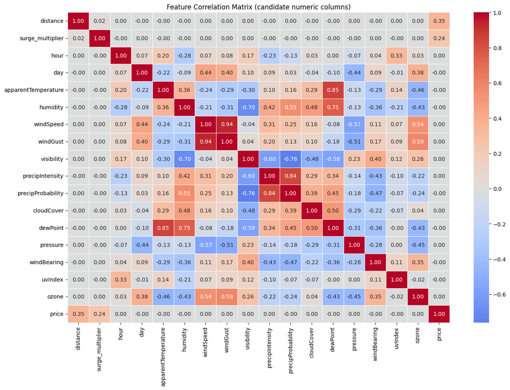

```
Correlation — windSpeed vs windGust: 0.9376

Correlation with price (target):
price                  1.0000
distance               0.3451
surge_multiplier       0.2405
visibility             0.0015
windGust               0.0012
windSpeed              0.0010
cloudCover             0.0009
pressure               0.0009
hour                   0.0006
ozone                  0.0005
precipIntensity        0.0002
apparentTemperature   -0.0002
precipProbability     -0.0002
uvIndex               -0.0004
dewPoint              -0.0006
day                   -0.0007
humidity              -0.0012
windBearing           -0.0014
Name: price, dtype: float64
```

```python
# ─────────────────────────────────────────────────────────
# Step 2.2: EDA — Correlation Analysis (on raw numeric cols)
# ─────────────────────────────────────────────────────────

# Numeric columns from df_raw that we are considering as features
candidate_numeric_cols = [
    'distance', 'surge_multiplier', 'hour', 'day',
    'apparentTemperature', 'humidity', 'windSpeed', 'windGust',
    'visibility', 'precipIntensity', 'precipProbability', 'cloudCover',
    'dewPoint', 'pressure', 'windBearing', 'uvIndex', 'ozone',
    'price'   # target
]

corr_matrix = df_raw[candidate_numeric_cols].corr()

# Plot heatmap
plt.figure(figsize=(14, 10))
sns.heatmap(corr_matrix, annot=True, fmt='.2f', cmap='coolwarm',
            center=0, linewidths=0.5)
plt.title('Feature Correlation Matrix (candidate numeric columns)')
plt.tight_layout()
plt.show()

# windSpeed vs windGust specifically
print(f"Correlation — windSpeed vs windGust: "
      f"{df_raw['windSpeed'].corr(df_raw['windGust']):.4f}")

# All correlations with price, sorted
print(f"\nCorrelation with price (target):")
print(corr_matrix['price'].sort_values(ascending=False))
```

```python
# ─────────────────────────────────────────────────────────
# STEP 2.3: Final Column Selection
#
# Decisions from stats + correlation matrix:
#
# DROPPED (multicollinearity):
#   windSpeed       — 0.94 corr with windGust
#   dewPoint        — 0.85 corr with apparentTemperature, 0.75 with humidity
#   precipIntensity — 0.84 corr with precipProbability; precipProbability
#                     is more interpretable and has better range
#
# DROPPED (no causal link to price):
#   pressure, windBearing, ozone — no logical pathway to ride pricing
#   uvIndex — 75th pct = 0, max = 2; no signal in Boston December
#
# KEPT (weather → demand → surge → price logic):
#   apparentTemperature, humidity, windGust, visibility,
#   precipProbability, cloudCover
#   Rationale: weather affects rider discomfort and booking decisions,
#   which drives surge multiplier, which directly affects price.
#   The MLP can learn these non-linear relationships even where
#   linear correlation with price appears near-zero.
# ─────────────────────────────────────────────────────────

COLS = [
    # Ride features
    'cab_type',             # Uber vs Lyft
    'name',                 # ride tier: UberX, Black, Shared, Lyft XL...
    'source',               # pickup neighbourhood (12 unique Boston areas)
    'destination',          # dropoff neighbourhood (12 unique Boston areas)
    'distance',             # trip distance in miles — strongest predictor (r=0.35)
    'surge_multiplier',     # demand multiplier — direct pricing component (r=0.24)

    # Time features
    'hour',                 # 0–23 — peak demand patterns
    'day',                  # 1–30 — end-of-month / holiday patterns

    # Weather features — ride-level conditions
    # pathway: weather → discomfort → demand → surge → price
    'apparentTemperature',  # feels-like °F — rider comfort signal
    'humidity',             # 0–1 — discomfort driver
    'windGust',             # peak wind mph — dropped windSpeed (r=0.94 with windGust)
    'visibility',           # miles — captures fog independently of rain
    'precipProbability',    # 0–1 — best precipitation signal (dropped precipIntensity,
                            #        r=0.84 with precipProbability)
    'cloudCover',           # 0–1 — general weather gloominess

    # TARGET
    'price',
]

df = df_raw[COLS].copy()
print(f"Selected columns shape: {df.shape}")
print(f"Number of features (excluding target): {len(COLS) - 1}")
print(f"\nMissing values:\n{df.isnull().sum()}")
```

```
Selected columns shape: (693071, 15)
Number of features (excluding target): 14

Missing values:
cab_type                   0
name                       0
source                     0
destination                0
distance                   0
surge_multiplier           0
hour                       0
day                        0
apparentTemperature        0
humidity                   0
windGust                   0
visibility                 0
precipProbability          0
cloudCover                 0
price                  55095
dtype: int64
```

```python
# ─────────────────────────────────────────────────────────
# STEP 3: Handle Missing Values
#
# Only 'price' has missing values (55,095 rows = ~8% of data)
# These rows have no target value — cannot be used for training.
# Imputing a target variable is not valid — drop them.
# All 14 features are fully complete — no feature imputation needed.
# ─────────────────────────────────────────────────────────

df.dropna(subset=['price'], inplace=True)

print(f"Shape after dropping missing price rows: {df.shape}")
print(f"Rows removed: {len(df_raw) - len(df)}")
print(f"\nMissing values after drop:\n{df.isnull().sum()}")
print(f"\nPrice range: ${df['price'].min():.2f} – ${df['price'].max():.2f}")
```

```
Shape after dropping missing price rows: (637976, 15)
Rows removed: 55095

Missing values after drop:
cab_type               0
name                   0
source                 0
destination            0
distance               0
surge_multiplier       0
hour                   0
day                    0
apparentTemperature    0
humidity               0
windGust               0
visibility             0
precipProbability      0
cloudCover             0
price                  0
dtype: int64

Price range: $2.50 – $97.50
```

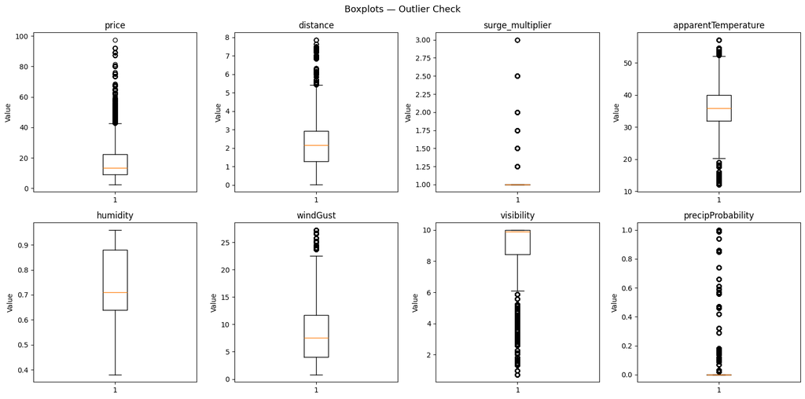

```
Outlier counts (beyond 1.5×IQR):
  price                 :   5589 outliers  | valid range [-11.25, 42.75]
  distance              :   6672 outliers  | valid range [-1.22, 5.42]
  surge_multiplier      :  20975 outliers  | valid range [1.00, 1.00]
  apparentTemperature   :  49208 outliers  | valid range [19.76, 52.16]
  humidity              :      0 outliers  | valid range [0.28, 1.24]
  windGust              :  15501 outliers  | valid range [-7.46, 23.26]
  visibility            : 125857 outliers  | valid range [6.09, 12.34]
  precipProbability     : 138748 outliers  | valid range [0.00, 0.00]
```

```python
# ─────────────────────────────────────────────────────────
# STEP 4.1: Outlier Check
# ─────────────────────────────────────────────────────────

fig, axes = plt.subplots(2, 4, figsize=(16, 8))
axes = axes.flatten()

numeric_features = [
    'price', 'distance', 'surge_multiplier',
    'apparentTemperature', 'humidity', 'windGust',
    'visibility', 'precipProbability'
]

for ax, col in zip(axes, numeric_features):
    ax.boxplot(df[col].dropna(), vert=True)
    ax.set_title(col)
    ax.set_ylabel('Value')

plt.suptitle('Boxplots — Outlier Check', fontsize=13)
plt.tight_layout()
plt.show()

# Print IQR-based outlier counts for each numeric column
print("Outlier counts (beyond 1.5×IQR):")
for col in numeric_features:
    Q1  = df[col].quantile(0.25)
    Q3  = df[col].quantile(0.75)
    IQR = Q3 - Q1
    lower = Q1 - 1.5 * IQR
    upper = Q3 + 1.5 * IQR
    n_outliers = ((df[col] < lower) | (df[col] > upper)).sum()
    print(f"  {col:<22}: {n_outliers:>6} outliers  "
          f"| valid range [{lower:.2f}, {upper:.2f}]")
```

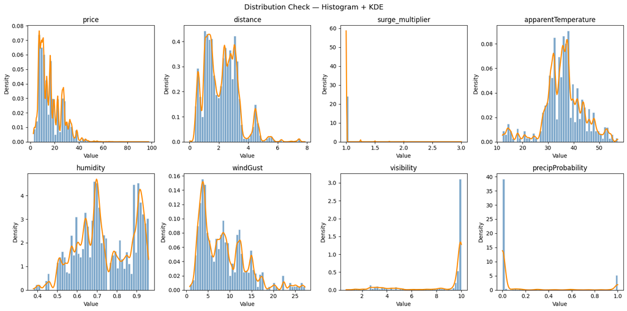

```
Column                      Skewness   Kurtosis              Verdict
----------------------------------------------------------------------
  price                       1.0457     1.2248        highly skewed
  distance                    0.8168     1.1515    moderately skewed
  surge_multiplier            7.9690    73.7982        highly skewed
  apparentTemperature        -0.3936     1.1377        approx normal
  humidity                   -0.0748    -1.0271        approx normal
  windGust                    1.1184     1.1532        highly skewed
  visibility                 -1.5081     0.6402        highly skewed
  precipProbability           2.0293     2.3416        highly skewed
```

```python
# ─────────────────────────────────────────────────────────
# STEP 4.2: Distribution Check
# Boxplot flagged many outliers — but IQR method assumes
# roughly normal distribution. Let's verify before acting.
# ─────────────────────────────────────────────────────────
from scipy import stats

numeric_features = [
    'price', 'distance', 'surge_multiplier',
    'apparentTemperature', 'humidity', 'windGust',
    'visibility', 'precipProbability'
]

# Plot histograms + KDE to visually check distribution shape
fig, axes = plt.subplots(2, 4, figsize=(16, 8))
axes = axes.flatten()

for ax, col in zip(axes, numeric_features):
    ax.hist(df[col], bins=50, density=True,
            color='steelblue', edgecolor='white', alpha=0.7)
    kde_x = np.linspace(df[col].min(), df[col].max(), 200)
    kde   = stats.gaussian_kde(df[col])
    ax.plot(kde_x, kde(kde_x), color='darkorange', linewidth=2)
    ax.set_title(col)
    ax.set_xlabel('Value')
    ax.set_ylabel('Density')

plt.suptitle('Distribution Check — Histogram + KDE', fontsize=13)
plt.tight_layout()
plt.show()

# Skewness and Kurtosis — quantitative normality indicators
# Normal distribution: skewness ≈ 0, kurtosis ≈ 0
# |skewness| > 1 → significantly skewed → IQR method unreliable
# kurtosis  > 3 → heavy tails → more extreme values than normal
print(f"\n{'Column':<25} {'Skewness':>10} {'Kurtosis':>10} {'Verdict':>20}")
print("-" * 70)
for col in numeric_features:
    skew = df[col].skew()
    kurt = df[col].kurt()
    if abs(skew) < 0.5:
        verdict = 'approx normal'
    elif abs(skew) < 1.0:
        verdict = 'moderately skewed'
    else:
        verdict = 'highly skewed'
    print(f"  {col:<23} {skew:>10.4f} {kurt:>10.4f} {verdict:>20}")
```